# Predicting the Unpredictable: Should You Really Be Worried about the Big One?

BY KATJA MCKIERNAN AND KATYA KELLY  
DECEMBER 17 2017

Earthquakes are one of the most unpredictable natural disasters that occur in the western United States. As statisticians who also study geology and geography, we decided to tackle the challenge of making predictions about earthquakes. We’re both from cities that have been tormented by a variety of media sources warning of the impending “Big One” (Los Angeles, California and Tacoma, Washington). Just take a peek at this 2015 article heading from *The New Yorker*:

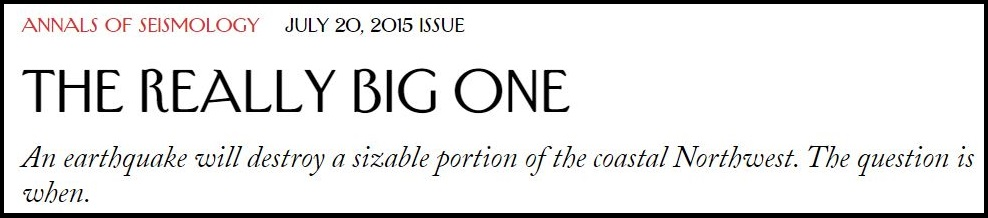

Scary, right? Pretty much the entire west coast was on high alert for a couple years, holding city-wide earthquake drills and demanding everyone take the time to nail their bookshelves to the walls. While the hype has since died down a little, we wanted to dive deeper into earthquake predictions. Although the Big One was rumored to possibly exceed a magnitude of 9.0 on the Richter Scale, we defined quakes of magnitude 7+ to be “big” for the sake of having enough data. The first question you might have is: how likely are we to see an earthquake this big in the next year? What about in the next five? We hope to approach an answer to these questions using Bayesian statistical modeling and regression.

# The Data

We collected all of our data from the United States Geological Survey (USGS) website. For predicting magnitude, we gathered 4700 observations of earthquakes above a magnitude of 4.5 since the year 2000. For our yearly rate predictions, we have 88 observations of earthquakes above a magnitude of 7 since 1900.

### Preliminary Exploration

To get acquainted with the data, we created maps to get a sense for where the earthquakes in our data set were occurring. Using the `ggmap` package, we were able to use our latitude and longitude data to plot the earthquakes directly on base maps pulled from Google Maps. Each set of maps shows all earthquakes in the top two maps and only large earthquakes in the bottom two. First, we have earthquakes by their magnitudes:

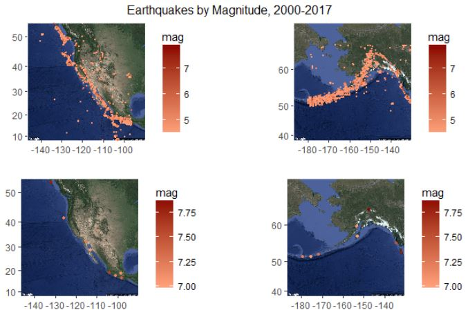

Next, we plotted by year:

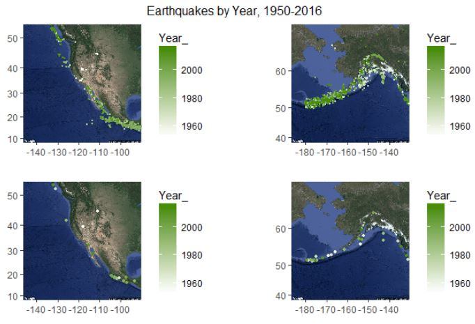

Firstly and importantly, our maps reflect current geological knowledge of plate boundaries, yay! Secondly, you may notice that there are far more smaller/moderate earthquakes than larger ones, with magnitudes 4.5-5 being the most common. This is what we would expect both based on personal knowledge and general earthquake knowledge (looks like those geology and geography minors are useful after all). As far as yearly trends go, it appears that there may be more earthquakes overall in the past 20 years than in the 1950s. That being said, it is possible that smaller earthquakes were not recorded as reliably in earlier years as they are today. Although there aren’t any obvious trends, these maps still gave us a few ideas for our analysis. What if we started with a simpler model relating magnitude to geographic region, then moved into a more complex model to estimate the yearly rate of earthquakes? These models would certainly be of significance to those living in earthquake-prone areas.

# Predicting magnitude of the next quake

### The Model

To start off simple, something that may be helpful or interesting to know is how big you can expect the next earthquake to be. Many small earthquakes happen daily in Alaska and on the west coast of the US, where we will focus our analysis. For this reason, we chose to make predictions about earthquakes that people are likely to actually feel.

Our data set consists of all magnitude 4.5+ earthquakes in North America from 2000-2017. We added a column to the data that specifies the broad region in which each quake occurred: Alaska, Canada, Hawaii, Mexico, or US. Below are some boxplots we used to explore the relationship between region and magnitude, where magnitude is log-transformed to account for expected skew:

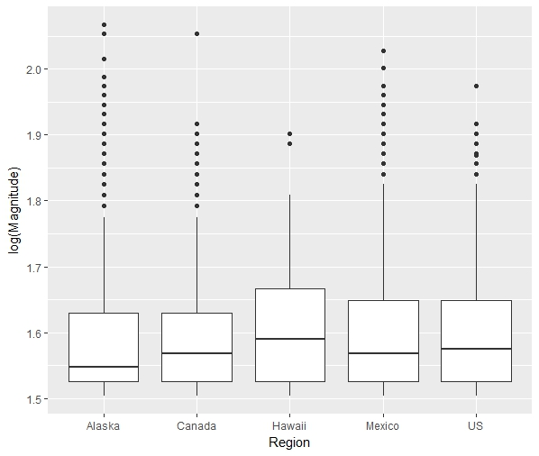

From these plots, there appear to be small differences in median magnitudes and in variation by region. Okay, we know — there’s nothing especially fascinating going on here, but it’s worth an exploration. We can construct a model that we believe captures some of the observed trends. If we let $M_i$ represent the magnitude of earthquake $i$ and $X_i$ be the region in which earthquake $i$ occurred, then we can obtain the following model and priors:

$$\log(M_i)|\beta_0, \beta_1, \tau_0, \tau_1 \sim N(\beta_0 + \beta_{1i}X_i, (\tau_0 + \tau_{1i}X_i)^{-1})$$
$$\beta_0, \beta_{1i} \sim N(0, 100^2)$$
$$\tau_0 \sim N(10,100^2)$$
$$\tau_{1i} \sim N(0, 100^2)$$

According to this model, we assume that log(magnitude) is Normally distributed. We allow each region its own error term to account for the differences in variation we saw in the boxplots. $\beta_0$ refers to our base expected posterior magnitude for Alaska, and $\tau_0$ is the base precision, which is equivalent to the inverse of variance. Since $X_i$ is a categorical variable, we set Alaska as a reference group and estimate $\beta_{1i}$ and $\tau_{1i}$ as differences from the reference. The regions are in alphabetical order so that beta1[1] is Alaska, followed by Canada, Hawaii, Mexico, and the US (beta1[2], beta1[3], beta1[4], and beta1[5], respectively). Our prior understanding of the parameters $\beta_0, \beta_{i1}, \tau_0$ and $\tau_{1i}$ is vague — we assign an uninformative mean and arbitrarily large variance to each.